# DNN,_CNN

Гузь Владислав, лабораторна 4.

```python
import numpy as np
import tensorflow as tf
import matplotlib.pyplot as plt
import pandas as pd
```

Завантажуємо та нормалізуємо дані.

```python
(trainx, trainy), (validx, validy) = tf.keras.datasets.cifar10.load_data()
trainx = trainx.astype(np.float32)/255.0
validx = validx.astype(np.float32)/255.0
```

```python
trainx = trainx.reshape((trainx.shape[0], trainx.shape[1] * trainx.shape[2] * trainx.shape[3]))
validx = validx.reshape((validx.shape[0], validx.shape[1] * validx.shape[2] * validx.shape[3]))
```

Проводимо навчання 30 моделей:

1. 10 моделей з активатором SIGMOID;
2. 10 моделей з активатором RELU;
3. 10 моделей з активатором TANH;

Оптимізатор - ADAM, розмір батчу - 32, кількість епох - 10, кількість нейронів - 32 на кожен слой крім вихідного. Навчання проводимо на нормалізованному датасеті

```python
models = dict()
histories = dict()
evals = dict()
layers = dict()
batch_size = 32
neurons = 32
opt = tf.keras.optimizers.Adam()
loss_scc = tf.keras.losses.SparseCategoricalCrossentropy(from_logits=True)
activators = ['sigmoid', 'relu', 'tanh']

for activator in activators:
  layers[activator] = []
  for i in range(10):
    current_layers = []
    for j in range(i+1):
      current_layers.append(tf.keras.layers.Dense(neurons, activation=activator))
    current_layers.append(tf.keras.layers.Dense(10))
    layers[activator].append(current_layers)

for activator in activators:
  models[activator] = []
  for k in range(10):
    new_layers = layers[activator][9-k:].copy()
    current = tf.keras.Sequential(layers[activator][k])
    current.compile(optimizer=opt, loss=loss_scc, metrics=['accuracy'])
    models[activator].append(current)

for activator in models.keys():
  histories[activator] = []
  evals[activator] = []
  for current in models[activator]:
    current_history = current.fit(x=trainx, y=trainy, batch_size=32, epochs=10, validation_data=(validx, validy))
    histories[activator].append(current_history)
    evals[activator].append(current.evaluate(x=validx, y=validy))
```

Будуємо 5 графіків:

1. Залежності точності від епох по всім моделям;
2. Залежності точності від епох по моделям з активатором SIGMOID;
3. Залежності точності від епох по моделям з активатором RELU;
4. Залежності точності від епох по моделям з активатором TANH;
5. Залежності кінцевої точності від кількості слоїв для кожного з активаторів окремо.

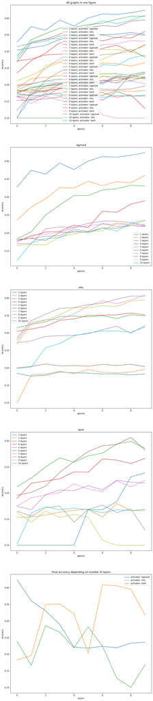

```python
from warnings import filterwarnings

filterwarnings('ignore')

plt.figure(figsize=(12, 60))
act = list(models.keys())
for i in range(10):
  plt.subplot(5, 1, 2)
  acc1 = histories[act[0]][i].history['val_accuracy']
  plt.plot(acc1, label="{} layers".format(i+1))
  plt.subplot(5, 1, 3)
  acc2 = histories[act[1]][i].history['val_accuracy']
  plt.plot(acc2, label="{} layers".format(i+1))
  plt.subplot(5, 1, 4)
  acc3 = histories[act[2]][i].history['val_accuracy']
  plt.plot(acc3, label="{} layers".format(i+1))

  plt.subplot(5, 1, 1)
  acc1 = histories[act[0]][i].history['val_accuracy']
  plt.plot(acc1, label="{} layers, activator: {}".format(i+1, act[0]))
  acc2 = histories[act[1]][i].history['val_accuracy']
  plt.plot(acc2, label="{} layers, activator: {}".format(i+1, act[1]))
  acc3 = histories[act[2]][i].history['val_accuracy']
  plt.plot(acc3, label="{} layers, activator: {}".format(i+1, act[2]))

plt.subplot(5, 1, 1)
plt.title("All graphs in one figure")
plt.xlabel('epochs')
plt.ylabel('acuuracy')
plt.legend()
plt.subplot(5, 1, 2)
plt.title(act[0])
plt.xlabel('epochs')
plt.ylabel('acuuracy')
plt.legend()
plt.subplot(5, 1, 3)
plt.title(act[1])
plt.xlabel('epochs')
plt.ylabel('acuuracy')
plt.legend()
plt.subplot(5, 1, 4)
plt.title(act[2])
plt.xlabel('epochs')
plt.ylabel('acuuracy')
plt.legend()

plt.subplot(5, 1, 5)
plt.plot(np.array(evals[act[0]])[:, 1:].reshape(1, -1)[0], label="activator: {}".format(act[0]))
plt.plot(np.array(evals[act[1]])[:, 1:].reshape(1, -1)[0], label="activator: {}".format(act[1]))
plt.plot(np.array(evals[act[2]])[:, 1:].reshape(1, -1)[0], label="activator: {}".format(act[2]))
plt.title("Final accuracy depending on number of layers")
plt.xlabel('layers')
plt.ylabel('acuuracy')
plt.legend()

plt.show()
```

Параметри: активатор: RELU, оптимізатор: ADAM, розмір батчу - 32. Також додамо 2 щільних слої і 1 для класифікації. Кількість епох - 10.

Також, додамо слої Dropout та BatchNormalization

```python
(trainx, trainy), (validx, validy) = tf.keras.datasets.cifar10.load_data()
trainx = trainx.astype(np.float32)/255.0
validx = validx.astype(np.float32)/255.0
```

```
Downloading data from https://www.cs.toronto.edu/~kriz/cifar-10-python.tar.gz
```

```python
opt = tf.keras.optimizers.Adam()
loss_scc = tf.keras.losses.SparseCategoricalCrossentropy(from_logits=True)
model = tf.keras.Sequential()
model.add(tf.keras.layers.Conv2D(32, (3, 3), activation='relu', input_shape=(32, 32, 3)))
model.add(tf.keras.layers.MaxPooling2D((2, 2)))
model.add(tf.keras.layers.Conv2D(64, (3, 3), activation='relu'))
model.add(tf.keras.layers.MaxPooling2D((2, 2)))
model.add(tf.keras.layers.Conv2D(64, (3, 3), activation='relu'))
model.add(tf.keras.layers.BatchNormalization())
model.add(tf.keras.layers.Dropout(rate=0.5))
model.add(tf.keras.layers.Flatten())
model.add(tf.keras.layers.Dense(32, activation='relu'))
model.add(tf.keras.layers.Dense(32, activation='relu'))
model.add(tf.keras.layers.Dense(10))
model.compile(optimizer=opt, loss=loss_scc, metrics=['accuracy'])
```

```python
result = model.fit(trainx, trainy, batch_size=32, epochs=10, validation_data=(validx, validy))
```

Подивимось, як змінювались втрати:

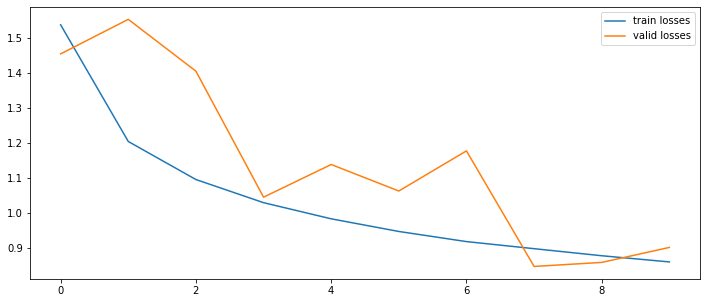

```python
plt.figure(figsize=(12, 5))
plt.plot(result.history['loss'], label='train losses')
plt.plot(result.history['val_loss'], label='valid losses')
plt.legend()
plt.show()
```

З цього графіку можна побачити, що втрати спадали для тестового та валідаційного датасетів, причому, перенавчання наче не відбулось (нема такого що втрати на валідаційному набагато більші).

Досягнута точність:

```python
model.evaluate(x=validx, y=validy)
```

```
[0.9015328884124756, 0.6887000203132629]
```

Висновок.

Натреновано 30 щільних НН:

1. 10 моделей з активатором SIGMOID;
2. 10 моделей з активатором RELU;
3. 10 моделей з активатором TANH;

Для такого типу класифікації дійсно краще підходять згорткові нейронні мережі: досягнута точність майже 70% без перенавчання, параметри: активатор: RELU, оптимізатор: ADAM, розмір батчу - 32. Також додамо 2 щільних слої і 1 для класифікації. Кількість епох - 10.